# R Notebook

```r
library(tidyverse)
library(mosaic)
library(mosaicData)
library(fastDummies)
library(GGally)
```

```r
library(datasauRus)
```

```r
datasaurus_dozen %>%
  group_by(dataset) %>%
  summarize(mean_x = mean(x),
            mean_y = mean(y),
            std_dev_x = sd(x),
            std_dev_y = sd(y),
            correlation  = cor(x, y))
```

| dataset | mean_x | mean_y | std_dev_x | std_dev_y | correlation |
| --- | --- | --- | --- | --- | --- |
| away | 54.26610 | 47.83472 | 16.76982 | 26.93974 | -0.06412835 |
| bullseye | 54.26873 | 47.83082 | 16.76924 | 26.93573 | -0.06858639 |
| circle | 54.26732 | 47.83772 | 16.76001 | 26.93004 | -0.06834336 |
| dino | 54.26327 | 47.83225 | 16.76514 | 26.93540 | -0.06447185 |
| dots | 54.26030 | 47.83983 | 16.76774 | 26.93019 | -0.06034144 |
| h_lines | 54.26144 | 47.83025 | 16.76590 | 26.93988 | -0.06171484 |
| high_lines | 54.26881 | 47.83545 | 16.76670 | 26.94000 | -0.06850422 |
| slant_down | 54.26785 | 47.83590 | 16.76676 | 26.93610 | -0.06897974 |
| slant_up | 54.26588 | 47.83150 | 16.76885 | 26.93861 | -0.06860921 |
| star | 54.26734 | 47.83955 | 16.76896 | 26.93027 | -0.06296110 |

[output cut: 3 more lines]

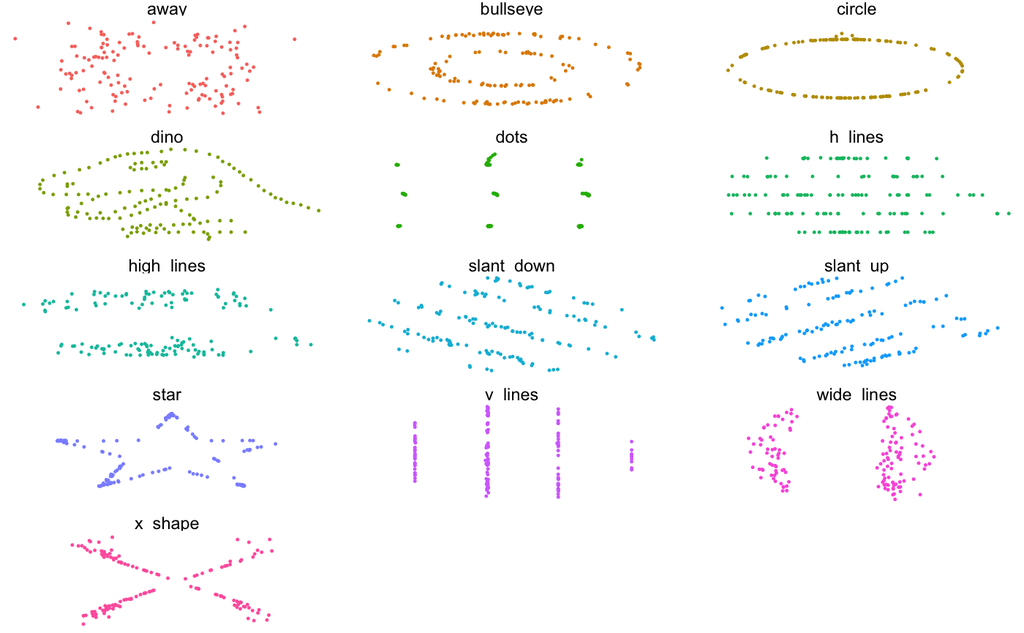

```r
datasaurus_dozen %>%
ggplot(aes(x = x, y = y, colour = dataset))+
  geom_point(size = 0.2)+
  theme_void()+
  theme(legend.position = "none")+
  facet_wrap(~ dataset, ncol = 3)
```

### Missing Values

- keep (may not be an option for some modelling)
- drop
- impute (replace with something meaningful)

```r
grades <- read_csv("data/grades.csv")
```

```r
head(grades)
```

| subject | assignment | tutorial | midterm | take_home | final |
| --- | --- | --- | --- | --- | --- |
| english | 57.14 | 34.09 | 64.38 | 51.48 | 52.50 |
| physics | 95.05 | 105.49 | 67.50 | 99.07 | 68.33 |
| physics | 83.70 | 83.17 | 30.00 | 63.15 | 48.89 |
| maths | 81.22 | 96.06 | 49.38 | 105.93 | 80.56 |
| physics | 91.32 | 93.64 | 95.00 | 107.41 | 73.89 |
| maths | 95.00 | 92.58 | 93.12 | 97.78 | 68.06 |

Is there a way we can model a student’s final grade?

y = final

Find out what missing values there are

```r
summary(grades)
```

```
   subject            assignment        tutorial         midterm         take_home          final
 Length:99          Min.   : 28.14   Min.   : 34.09   Min.   : 28.12   Min.   : 16.91   Min.   : 28.06
 Class :character   1st Qu.: 80.88   1st Qu.: 83.35   1st Qu.: 52.81   1st Qu.: 66.02   1st Qu.: 53.12
 Mode  :character   Median : 89.94   Median : 93.10   Median : 69.38   Median : 87.96   Median : 66.25
                    Mean   : 85.49   Mean   : 89.73   Mean   : 68.05   Mean   : 80.83   Mean   : 68.41
                    3rd Qu.: 95.00   3rd Qu.:100.55   3rd Qu.: 82.81   3rd Qu.: 98.75   3rd Qu.: 84.17
                    Max.   :100.83   Max.   :112.58   Max.   :110.00   Max.   :108.89   Max.   :108.89
                                                                       NA's   :1        NA's   :3
```

[output not shown]

[output cut: 89 more lines]

Imputing missing values can be very valuable in modelling as it:

- retains the information from other predictors
- doesn’t throw off the regression too much when using ‘sensible’ values

### Dealing with outliers

- don’t be hasty to drop ‘outliers’
- be sure to justify the removal of any outliers
- model it twice and report the difference when outliers are removed

### Transformations

When we’ve got very skewed data, one strategy is to transform the variable (usually using the variable itself)

We can reduce the effect of skew by:

- taking exponents (left-skew)
- taking logarithms (right_skew)
- taking square / sqrt

A way to convert non-linear relationships into linear relationships

Example

gdp = -9 * population + 90 with transformation: gdp = 2.3 * log(population) + 90

### Categorical Data in a Model

- convert into a wide format
- each categorical level is a variable
  - turns the categories into ‘switches’
  - if maths is ‘switched on’, what will the final grade be?
  - if english is ‘switched on’, what will the final grade be?
  - y = slope maths * maths + intercept
  - process is called: “Creating Dummy Variables”

#### Create Dummy Variable long-form

We wouldn’t actually do this as we have packages

```r
grades_dummy <- grades %>%
  mutate(english = if_else(subject == "english", 1, 0),
         physics = if_else(subject == "physics", 1, 0),
         maths = if_else(subject == "maths", 1, 0),
         french = if_else(subject == "french", 1, 0),
         biology = if_else(subject == "biology", 1, 0)) %>%
  select(-subject)
grades_dummy
```

| assignment | tutorial | midterm | take_home | final | english | physics | maths | french | biology |
| --- | --- | --- | --- | --- | --- | --- | --- | --- | --- |
| 57.14 | 34.09 | 64.38 | 51.48000 | 52.50000 | 1 | 0 | 0 | 0 | 0 |
| 95.05 | 105.49 | 67.50 | 99.07000 | 68.33000 | 0 | 1 | 0 | 0 | 0 |
| 83.70 | 83.17 | 30.00 | 63.15000 | 48.89000 | 0 | 1 | 0 | 0 | 0 |
| 81.22 | 96.06 | 49.38 | 105.93000 | 80.56000 | 0 | 0 | 1 | 0 | 0 |
| 91.32 | 93.64 | 95.00 | 107.41000 | 73.89000 | 0 | 1 | 0 | 0 | 0 |
| 95.00 | 92.58 | 93.12 | 97.78000 | 68.06000 | 0 | 0 | 1 | 0 | 0 |
| 95.05 | 102.99 | 56.25 | 99.07000 | 50.00000 | 0 | 1 | 0 | 0 | 0 |
| 72.85 | 86.85 | 60.00 | 80.82847 | 56.11000 | 0 | 0 | 1 | 0 | 0 |
| 84.26 | 93.10 | 47.50 | 18.52000 | 50.83000 | 0 | 1 | 0 | 0 | 0 |
| 90.10 | 97.55 | 51.25 | 88.89000 | 63.61000 | 0 | 0 | 1 | 0 | 0 |

[output cut: 89 more lines]

If maths, physics, french and biology are 0, we know **english = 1**

##### Dummy Variable Trap

- we don’t want to have the same information in our model twice
- we are giving a variable that should have a weight of 1, a weight of 2
- multicollinearity - having a copy of a variable in a model
- we can avoid this by not having one of the variables present

```r
# remove biology to avoid multicollinearity
grades_dummy <- grades %>%
  mutate(english = if_else(subject == "english", 1, 0),
         physics = if_else(subject == "physics", 1, 0),
         maths = if_else(subject == "maths", 1, 0),
         french = if_else(subject == "french", 1, 0)) %>%
  select(-subject)

grades_dummy
```

[output not shown]

#### Real Dummy Variables

1. R does dummies automatically when using lm() or gm()

```r
lm(Sepal.Length ~ ., iris)
```

```
Call:
lm(formula = Sepal.Length ~ ., data = iris)

Coefficients:
      (Intercept)        Sepal.Width       Petal.Length        Petal.Width  Speciesversicolor   Speciesvirginica
           2.1713             0.4959             0.8292            -0.3152            -0.7236            -1.0235
```

```r
grades_dummies <- grades %>%
  dummy_cols(
    select_columns = "subject",
    remove_first_dummy = TRUE, # to avoid multicollinearity / dummy variable trap
    remove_selected_columns = TRUE
  )

grades_dummies
```

| assignment | tutorial | midterm | take_home | final | subject_english | subject_french | subject_maths | subject_physics |
| --- | --- | --- | --- | --- | --- | --- | --- | --- |
| 57.14 | 34.09 | 64.38 | 51.48000 | 52.50000 | 1 | 0 | 0 | 0 |
| 95.05 | 105.49 | 67.50 | 99.07000 | 68.33000 | 0 | 0 | 0 | 1 |
| 83.70 | 83.17 | 30.00 | 63.15000 | 48.89000 | 0 | 0 | 0 | 1 |
| 81.22 | 96.06 | 49.38 | 105.93000 | 80.56000 | 0 | 0 | 1 | 0 |
| 91.32 | 93.64 | 95.00 | 107.41000 | 73.89000 | 0 | 0 | 0 | 1 |
| 95.00 | 92.58 | 93.12 | 97.78000 | 68.06000 | 0 | 0 | 1 | 0 |
| 95.05 | 102.99 | 56.25 | 99.07000 | 50.00000 | 0 | 0 | 0 | 1 |
| 72.85 | 86.85 | 60.00 | 80.82847 | 56.11000 | 0 | 0 | 1 | 0 |
| 84.26 | 93.10 | 47.50 | 18.52000 | 50.83000 | 0 | 0 | 0 | 1 |
| 90.10 | 97.55 | 51.25 | 88.89000 | 63.61000 | 0 | 0 | 1 | 0 |

[output cut: 89 more lines]

We might want to group together low frequency categories

```r
grades %>%
  mutate(
    subject = if_else(
      subject %in% c("maths", "physics"), subject, "other"
    )
  )
```

| subject | assignment | tutorial | midterm | take_home | final |
| --- | --- | --- | --- | --- | --- |
| other | 57.14 | 34.09 | 64.38 | 51.48000 | 52.50000 |
| physics | 95.05 | 105.49 | 67.50 | 99.07000 | 68.33000 |
| physics | 83.70 | 83.17 | 30.00 | 63.15000 | 48.89000 |
| maths | 81.22 | 96.06 | 49.38 | 105.93000 | 80.56000 |
| physics | 91.32 | 93.64 | 95.00 | 107.41000 | 73.89000 |
| maths | 95.00 | 92.58 | 93.12 | 97.78000 | 68.06000 |
| physics | 95.05 | 102.99 | 56.25 | 99.07000 | 50.00000 |
| maths | 72.85 | 86.85 | 60.00 | 80.82847 | 56.11000 |
| physics | 84.26 | 93.10 | 47.50 | 18.52000 | 50.83000 |
| maths | 90.10 | 97.55 | 51.25 | 88.89000 | 63.61000 |

[output cut: 89 more lines]

### Binning

Sometimes, it’s useful to group together continuous predictors

```r
grades %>%
  distinct(midterm) %>%
  nrow()
```

```
[1] 64
```

–> create a grade category

- > 70 = A
- > 60 = B
- > 50 = C

```r
grades %>%
  mutate(midterm_letter = case_when(
    midterm >= 70 ~ "A",
    midterm >= 60 ~ "B",
    midterm >= 50 ~ "C",
    TRUE ~ "F"
  ), .after = midterm)
```

| subject | assignment | tutorial | midterm | midterm_letter | take_home | final |
| --- | --- | --- | --- | --- | --- | --- |
| english | 57.14 | 34.09 | 64.38 | B | 51.48000 | 52.50000 |
| physics | 95.05 | 105.49 | 67.50 | B | 99.07000 | 68.33000 |
| physics | 83.70 | 83.17 | 30.00 | F | 63.15000 | 48.89000 |
| maths | 81.22 | 96.06 | 49.38 | F | 105.93000 | 80.56000 |
| physics | 91.32 | 93.64 | 95.00 | A | 107.41000 | 73.89000 |
| maths | 95.00 | 92.58 | 93.12 | A | 97.78000 | 68.06000 |
| physics | 95.05 | 102.99 | 56.25 | C | 99.07000 | 50.00000 |
| maths | 72.85 | 86.85 | 60.00 | B | 80.82847 | 56.11000 |
| physics | 84.26 | 93.10 | 47.50 | F | 18.52000 | 50.83000 |
| maths | 90.10 | 97.55 | 51.25 | C | 88.89000 | 63.61000 |

[output cut: 89 more lines]

sometimes we want to reduce the **granularity**, in these cases we’d group observations into bins

### Deriving Variables

we call the initial data variables when we load them in: row variables

any columns we create are ‘derived variables’ - can be **super useful**

Perhaps BMI is a better predictor of someone’s health than either their height or weight

### Scaling Variables

Models don’t care about units

When we get very large values, 20000 vs 2, the model will care about the difference between these values. The model doesn’t care about context, only the values.

To bring our values onto a similar scale, we could scale them:

- standardisation (follows standard normal distribution (mean 0, sd 1))
- normalisation (follows normal distribution)

This isn’t particularly model-breaking for linear regression

Our baseline our predictor is 0, this is our response

When standardised our predictor is at its mean, this is our response

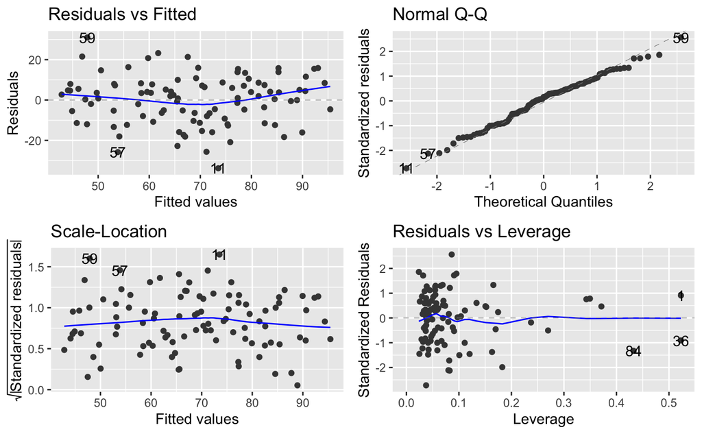

```r
library(ggfortify)
model_baseline <- lm(final ~ .,
                     data = grades)

autoplot(model_baseline)
```

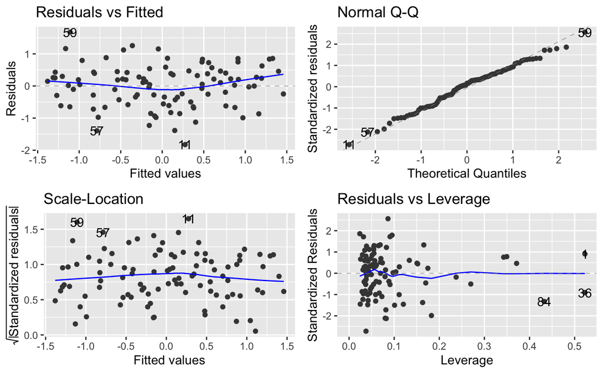

```r
grades_scaled <- grades %>%
  mutate(across(where(is.numeric), scale)) # how far away is it from a mean of 0 if everything is shifted

model_scaled <- lm(final ~ .,
                     data = grades_scaled)

autoplot(model_scaled)
```

```r
summary(model_baseline)
```

```
Call:
lm(formula = final ~ ., data = grades)

Residuals:
    Min      1Q  Median      3Q     Max
-33.794  -8.593   1.924   7.853  31.014

Coefficients:
               Estimate Std. Error t value Pr(>|t|)
(Intercept)     0.72468   13.12123   0.055   0.9561
subjectenglish -6.66295   12.34646  -0.540   0.5908
subjectfrench   5.08663    8.76859   0.580   0.5633
subjectmaths    7.43131    7.68719   0.967   0.3363
subjectphysics  8.91328    7.62822   1.168   0.2457
assignment      0.06609    0.12832   0.515   0.6078
tutorial        0.03858    0.11771   0.328   0.7439
midterm         0.61227    0.07529   8.133 2.17e-12 ***
take_home       0.11633    0.06941   1.676   0.0972 .
---
Signif. codes:  0 ‘***’ 0.001 ‘**’ 0.01 ‘*’ 0.05 ‘.’ 0.1 ‘ ’ 1

Residual standard error: 12.66 on 90 degrees of freedom
Multiple R-squared:  0.5704,    Adjusted R-squared:  0.5323
F-statistic: 14.94 on 8 and 90 DF,  p-value: 1.033e-13
```

```r
summary(model_scaled)
```

```
Call:
lm(formula = final ~ ., data = grades_scaled)

Residuals:
    Min      1Q  Median      3Q     Max
-1.8256 -0.4642  0.1040  0.4242  1.6754

Coefficients:
               Estimate Std. Error t value Pr(>|t|)
(Intercept)    -0.40572    0.39725  -1.021   0.3098
subjectenglish -0.35994    0.66698  -0.540   0.5908
subjectfrench   0.27479    0.47369   0.580   0.5633
subjectmaths    0.40145    0.41528   0.967   0.3363
subjectphysics  0.48151    0.41209   1.168   0.2457
assignment      0.04498    0.08733   0.515   0.6078
tutorial        0.03141    0.09584   0.328   0.7439
midterm         0.64088    0.07881   8.133 2.17e-12 ***
take_home       0.14886    0.08882   1.676   0.0972 .
---
Signif. codes:  0 ‘***’ 0.001 ‘**’ 0.01 ‘*’ 0.05 ‘.’ 0.1 ‘ ’ 1

Residual standard error: 0.6839 on 90 degrees of freedom
Multiple R-squared:  0.5704,    Adjusted R-squared:  0.5323
F-statistic: 14.94 on 8 and 90 DF,  p-value: 1.033e-13
```

The model hasn’t really changed. Our interpretation has been shifted though.

I want to make a model but…

- My data has missing values
  - **might impute them**
- My data has a couple of serious outliers
  - **we’d seriously justify dropping them**
- My data is highly right-skewed
  - **we’d transform the variable using log for example**
- My data is categorical
  - **we’d encode this using dummy variables**
- My data has too many unique values
  - **we’d group them together in bins to reduce the granularity**
- My data doesn’t have the best predictors
  - **we’d derive better ones**
- My data has variables that are measured in different units
  - **we’d consider scaling**